[figure not shown]

1

Ejercicios sugeridos sobre distribuciones continuas

Normal

Exponencial

Uniforme

Lognormal

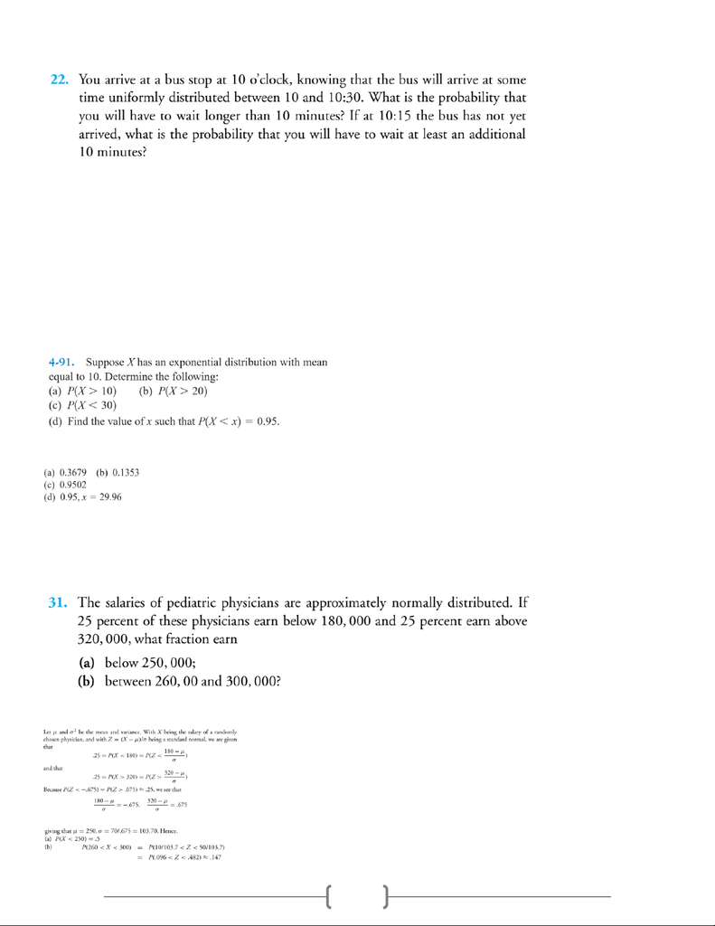

2

Ejercicio 5.22 de Ross (2014)

Rta: a: 2/3; b: 1/3.

Usando R:

punif(q=10, min=0, max=30, lower.tail=FALSE)

punif(q=25, min=0, max=30, lower.tail=FALSE) / punif(q=15, min=0, max=30, lower.tail=FALSE)

Ejercicio 4.91 de Montgomery (2011)

Rta:

Ejercicio 5.31 de Ross (2014)

Rta:

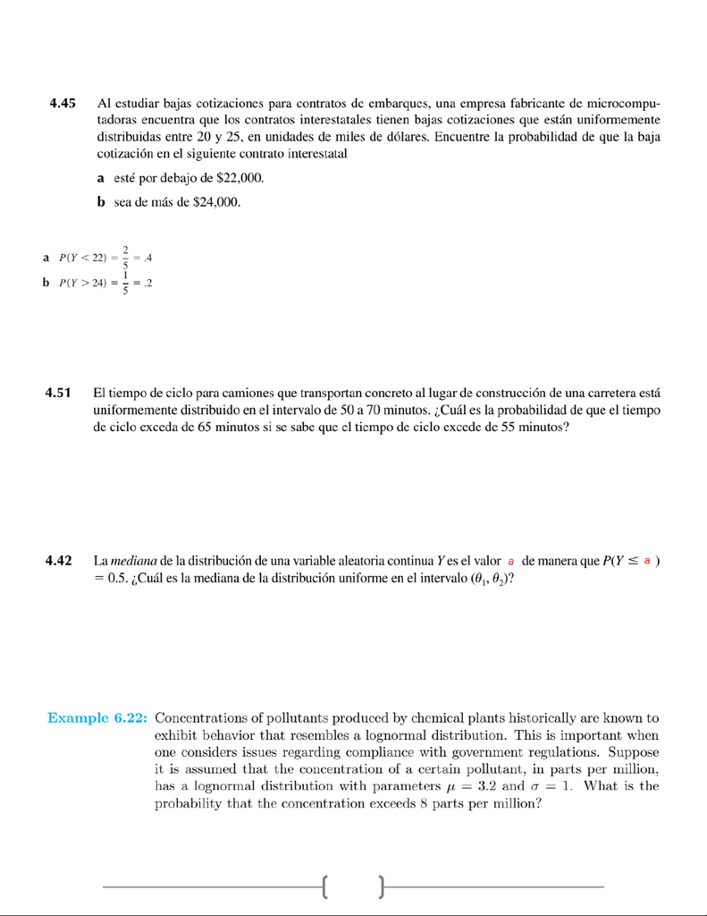

3

Ejercicio 4.45 de Wackerly (2010)

Rta:

Ejercicio 4.51 de Wackerly (2010)

Rta: 1/3.

Ejercicio 4.42 de Wackerly (2010)

Ejemplo 6.22 de Walpole (2012)

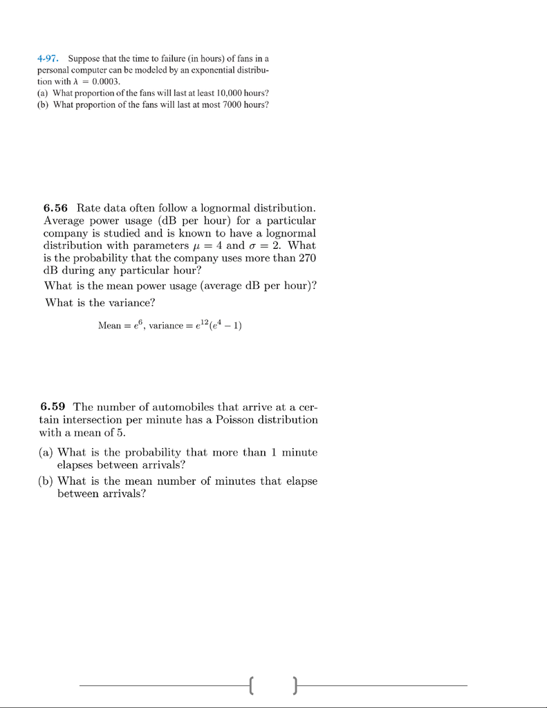

4

Ejercicio 4.97 de Montgomery (2010)

Rta: (a) 0.0498 (b) 0.8775

Ejercicio 6.56 de Walpole (2012)

Rta: 0.212084,

Ejercicio 6.59 de Walpole (2012)

Rta: pexp(q=1, rate=5, lower.tail=FALSE) y 1/5

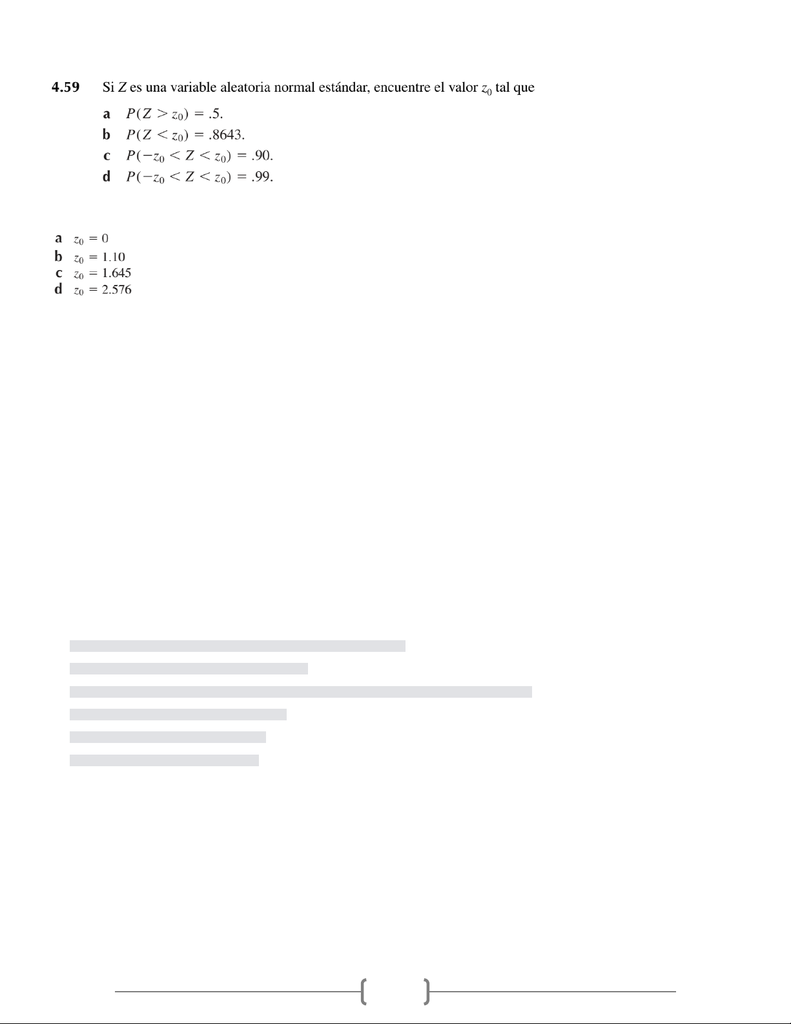

5

Ejercicio 4.59 de Wackerly (2010)

Rta:

1. El consumo promedio de combustible de una flota de 1000 camiones sigue una distribución normal con una

media de 12 millas por galón y una desviación estándar de 2 millas por galón. Escriba las instrucciones en R para

calcular cada una de las siguientes probabilidades.

a) ¿Cuántos camiones tendrán un promedio de 11 millas o más por galón?

b) ¿Cuántos camiones tendrán un promedio de menos de 10 millas por galón?

c) ¿Cuántos camiones tendrán un promedio entre 9.5 y 14 millas por galón?

d) Averigüe la probabilidad de que un camión elegido al azar tenga un promedio de 13.5 millas por galón

o más.

e) ¿El 70% de los camiones tuvo un promedio más alto que cuántas millas por galón?

f) ¿El 10% de los camiones tuvo un promedio menor que cuántas millas por galón?

Rtas:

1000 * pnorm(q=11, mean=12, sd=2, lower.tail=F);

1000 * pnorm(q=10, mean=12, sd=2);

1000 * (pnorm(q=14, mean=12, sd=2) - pnorm(q=9.5, mean=12, sd=2));

1-pnorm(q=13.5, mean=12, sd=2);

qnorm(p=0.3, mean=12, sd=2);

qnorm(p=0.1, mean=12, sd=2)

2. Una empresa ha encontrado que la duración de sus llamadas telefónicas a larga distancia, tiene

aproximadamente una distribución normal, con media de 30 minutos y desviación típica de 3 minutos. Escriba

el código en R para calcular lo siguiente.

a) ¿Qué proporción de las llamadas a larga distancia tienen una duración de más de 20 minutos, pero de

menos de 30 minutos?

b) ¿Qué proporción de llamadas se completan en 10 minutos o menos?

[figure not shown]

6

c) Una secretaria va a hacer una llamada a larga distancia. ¿Cuál es la probabilidad de que dure más de 50

minutos?

Rtas:

pnorm(q=10, mean=30, sd=3)

pnorm(q=50, mean=30, sd=3, lower.tail=FALSE)

3. El gerente de personal de una gran compañía requiere que los postulantes a un puesto efectúen una prueba

de aptitud y que en ella obtengan una calificación mínima de 500. Si las calificaciones de la prueba se distribuyen

normalmente con una media de 485 y desviación estándar de 30:

a) ¿Qué porcentaje de postulantes aprobará la prueba?

b) Si aquellos postulantes que obtienen un puntaje comprendido entre 471 y 499 pueden optar a una

segunda oportunidad, y un total de 1200 postulantes presentó la primera prueba, ¿cuántos de los 1200

postulantes tendrán derecho a presentar la prueba por segunda vez?

c) Si el puntaje de la segunda prueba se relaciona con el puntaje de la primera prueba a través de la

expresión: Y=1.25 X + 2.5, donde Y es el puntaje en la segunda prueba y X es el puntaje obtenido en la

primera prueba, determine la probabilidad de que en la segunda prueba un postulante cualquiera

elegido al azar obtenga el puntaje aprobatorio de 500 puntos o más.

d) Determine un puntaje “k” correspondiente al percentil 90 de la distribución. Interprete.

Rtas: pendientes.

4. ¿Cuáles de los siguientes enunciados son verdaderos?

a) La distribución normal es asimétrica

b) Es necesario conocer la media y la desviación estándar para construir una distribución normal específica.

c) Cada combinación de media y desviación estándar en una distribución normal define una densidad

diferente.

d) La distribución normal se extiende al infinito en cualquier dirección a partir de la media.

e) La distribución normal se mide en una escala discreta.

f) El área total bajo la curva es igual a 1.

g) La probabilidad de que una variable aleatoria tenga un valor entre dos puntos cualesquiera es igual al

área bajo la curva entre esos dos puntos.

h) La distribución normal estándar tiene media 1 y varianza 0.

i) La tabla de distribución normal estándar sirve para calcular probabilidades de cualquier distribución

normal.

j) Estandarizar un valor  significa restarle la desviación y dividir por la media.

k) La probabilidad de que una variable aleatoria continua tome un valor dado es cero.

l) La función de densidad de probabilidad (fdp) de una variable aleatoria continua sirve para conocer en

qué región es más probable encontrar valores de la variable.

Rtas: F, V, V, V, F, V, V, F, V, F, V, V.

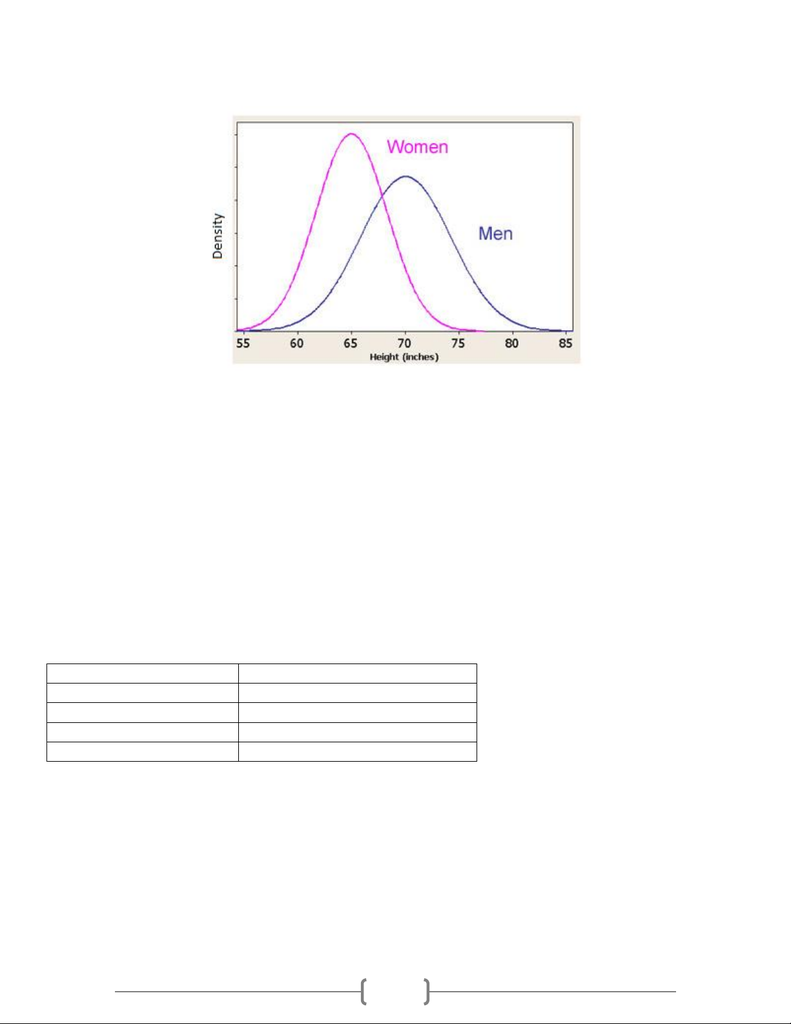

7

5. Observando la fdp de la figura siguiente determine si las siguientes afirmaciones son verdaderas o falsas.

a) Los hombres tienen un promedio de estatura mayor que el de las mujeres.

b) La estatura de las mujeres tiene mayor variabilidad porque la curva es más alta.

c) La distribución de las estaturas es simétrica.

d) Es más probable que un hombre tenga estatura entre 75 y 80 a que una mujer tenga estatura en

ese intervalo.

e) Debajo de la densidad de la estatura de las mujeres hay un área aproximada del 70%.

Rtas: T, F, T, T, F.

Tabla de organización de los ejercicios sugeridos.

Tema

Ejercicios

Uniforme

5.22, 4.45, 4.42, 4.51

Normal

5.31, 4.59, 1, 2, 3

Exponencial

4.91, 4.97, 6.59

Lognormal

6.22, 6.56

[figure not shown]

8